# Chapter 7 Functional diversity

The previous chapters used abundances and a phylogeny. Here we add the functional layer: genome-inferred traits distilled from KEGG ortholog annotations of the same 5,518 representative MAGs. Each MAG has a completeness score between zero and one for every function-level trait in the distillR biosynthesis and degradation domains, such as nucleic acid biosynthesis or polysaccharide degradation. We turn these traits into a functional distance between MAGs and use it in [hilldiv3](https://alberdilab.github.io/hilldiv3/) to calculate functional diversity and related metrics.

## 7.1 Functional traits

`scripts/distill-functional-traits.R` distils the primary KEGG ortholog hit of every gene (Drakkar 2.6.9, KOfam database of 2026-07-02) into trait tables. We use the function level, which has one column per function and the same row order as the representative metadata.

```r
functional_traits <- data.table::fread(
  cmd = "xz -dc data/mag_gift_functions.tsv.xz",
  data.table = FALSE, check.names = FALSE
)
stopifnot(identical(functional_traits$genome_id, genome_metadata$genome_id))
rownames(functional_traits) <- functional_traits$genome_id
functional_traits$genome_id <- NULL

# Protein degradation is defined by MEROPS peptidase families, which KEGG
# annotation cannot supply, so it is zero in every MAG and carries no signal.
empty_functions <- colnames(functional_traits)[colSums(functional_traits) == 0]
functional_traits <- functional_traits[, !colnames(functional_traits) %in%
                                         empty_functions, drop = FALSE]
stopifnot(identical(empty_functions, "D04"),
          all(as.matrix(functional_traits) >= 0 &
                as.matrix(functional_traits) <= 1))

function_labels <- unique(distillR::GIFT_db[c("Code_function", "Function",
                                              "Domain")])
function_labels <- function_labels[match(colnames(functional_traits),
                                         function_labels$Code_function), ]
stopifnot(!anyNA(function_labels$Function))
cat(sprintf("%d MAGs, %d function-level traits (%d biosynthesis, %d degradation).\n",
            nrow(functional_traits), ncol(functional_traits),
            sum(function_labels$Domain == "Biosynthesis"),
            sum(function_labels$Domain == "Degradation")))
```

```
5518 MAGs, 17 function-level traits (9 biosynthesis, 8 degradation).
```

## 7.2 Functional distance

`traits2dist()` converts the trait table to a Gower distance, the mean absolute difference in completeness across traits, scaled to the range of each trait. Two MAGs with identical traits are at distance zero.

```r
functional_dist <- hilldiv3::traits2dist(functional_traits, method = "gower")
```

```r
stopifnot(identical(dim(functional_dist), c(5518L, 5518L)),
          all(is.finite(functional_dist)))
dimnames(functional_dist) <- list(genome_metadata$genome_id,
                                  genome_metadata$genome_id)
pair_distance <- functional_dist[upper.tri(functional_dist)]
distance_quantiles <- stats::quantile(pair_distance,
                                      c(0.01, 0.25, 0.5, 0.75, 0.99, 1))
knitr::kable(
  data.frame(Statistic = c("1%", "25%", "Median", "75%", "99%", "Maximum"),
             Distance = unname(distance_quantiles)),
  digits = 3
)
```

| Statistic | Distance |
| --- | --- |
| 1% | 0.087 |
| 25% | 0.153 |
| Median | 0.188 |
| 75% | 0.234 |
| 99% | 0.452 |
| Maximum | 0.749 |

*Quantiles of the pairwise functional distance between the 5,518 representatives.*

Functional Hill numbers count the effective number of functionally distinct types in a sample. Two MAGs closer than a threshold $\tau$ count as largely the same type. We set $\tau$ to the mean pairwise distance, 0.20, and examine how sensitive the results are to this choice below.

```r
functional_tau <- mean(pair_distance)
```

## 7.3 Functional diversity within samples

We calculate neutral and functional Hill numbers at $q=0$, $q=1$ and $q=2$ from the same abundances. A `dist` supplied with `type = "functional"` adds the functional layer.

```r
fd_neutral <- hilldiv3::hilldiv(
  overview_abundance, q = c(0, 1, 2), type = "neutral"
)
fd_functional <- hilldiv3::hilldiv(
  overview_abundance, q = c(0, 1, 2), dist = functional_dist,
  tau = functional_tau, type = "functional"
)
```

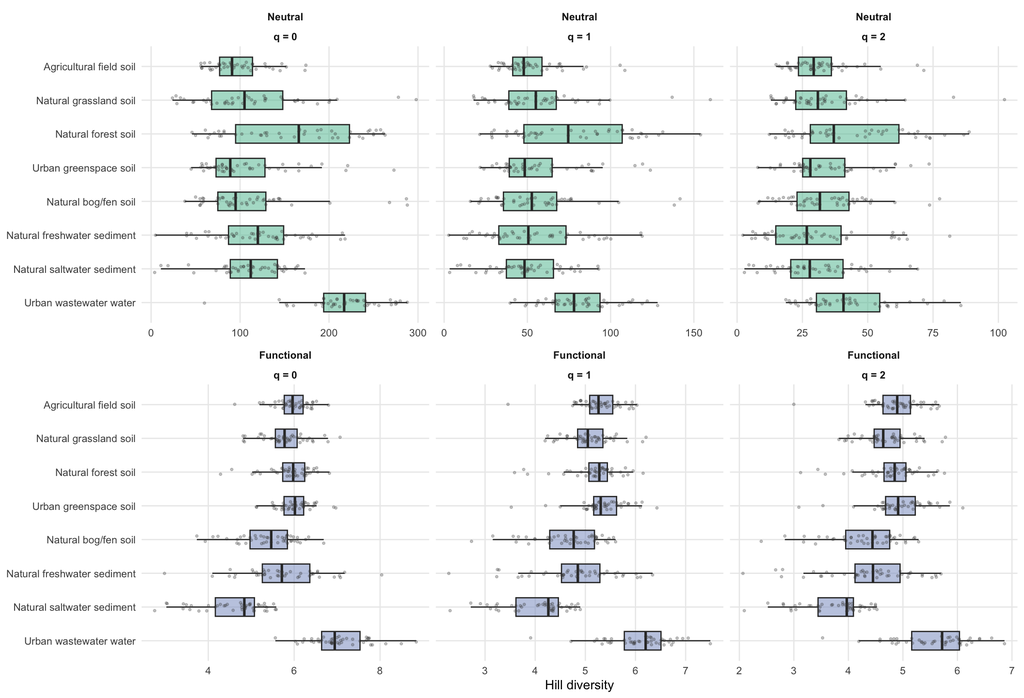

```r
ggplot2::ggplot(fd_alpha, ggplot2::aes(x = value, y = habitat, fill = type)) +
  ggplot2::geom_boxplot(outlier.shape = NA, width = 0.55, alpha = 0.55,
                        colour = "grey20") +
  ggplot2::geom_jitter(height = 0.13, width = 0, alpha = 0.28,
                       size = 0.65, colour = "grey25") +
  ggplot2::scale_fill_manual(values = type_colours, guide = "none") +
  ggplot2::facet_wrap(ggplot2::vars(type, order), ncol = 3,
                      scales = "free_x") +
  ggplot2::labs(x = "Hill diversity", y = NULL) +
  ggplot2::theme_minimal(base_size = 10) +
  ggplot2::theme(panel.grid.minor = ggplot2::element_blank(),
                 strip.text = ggplot2::element_text(face = "bold"))
```

*Neutral and functional Hill numbers for 45 samples in each habitat class. Horizontal scales differ by panel.*

```r
fd_q1 <- fd_alpha[fd_alpha$q == 1, ]
fd_wide <- reshape(
  fd_q1[c("sample", "habitat", "type", "value")], idvar = c("sample", "habitat"),
  timevar = "type", direction = "wide"
)
names(fd_wide) <- sub("value\\.", "", names(fd_wide))
fd_wide$Redundancy <- fd_wide$Neutral / fd_wide$Functional
fd_summary <- function(x) {
  sprintf("%.1f [%.1f–%.1f]", median(x), unname(quantile(x, 0.25)),
          unname(quantile(x, 0.75)))
}
fd_table <- data.frame(
  Habitat = habitat_levels,
  Neutral = tapply(fd_wide$Neutral, fd_wide$habitat, fd_summary)[habitat_levels],
  Functional = tapply(fd_wide$Functional, fd_wide$habitat,
                      fd_summary)[habitat_levels],
  Redundancy = tapply(fd_wide$Redundancy, fd_wide$habitat,
                      fd_summary)[habitat_levels]
)
rownames(fd_table) <- NULL
knitr::kable(fd_table, col.names = c("Habitat", "Neutral q = 1",
                                     "Functional q = 1",
                                     "Functional redundancy"))
```

| Habitat | Neutral q = 1 | Functional q = 1 | Functional redundancy |
| --- | --- | --- | --- |
| Agricultural field soil | 47.8 [41.2–58.8] | 5.3 [5.1–5.5] | 9.3 [7.6–11.2] |
| Natural grassland soil | 55.1 [38.9–67.3] | 5.0 [4.8–5.4] | 11.1 [7.5–13.1] |
| Natural forest soil | 74.5 [47.9–107.0] | 5.3 [5.1–5.4] | 13.8 [9.9–19.4] |
| Urban greenspace soil | 48.4 [39.1–64.9] | 5.3 [5.2–5.6] | 9.0 [7.6–11.9] |
| Natural bog/fen soil | 52.7 [35.6–67.6] | 4.8 [4.3–5.2] | 11.3 [9.1–13.2] |
| Natural freshwater sediment | 50.6 [32.8–73.2] | 4.9 [4.5–5.3] | 10.6 [7.7–14.8] |
| Natural saltwater sediment | 48.3 [37.4–65.7] | 4.3 [3.6–4.5] | 11.5 [9.5–15.4] |
| Urban wastewater water | 78.0 [66.6–93.6] | 6.2 [5.8–6.5] | 12.9 [11.2–15.8] |

*Median [interquartile range] of $q=1$ diversity by habitat. Functional redundancy is neutral divided by functional diversity: the number of effective MAGs per effective functional type.*

At $q=1$, median functional diversity ranges from 4.3 in Natural saltwater sediment to 6.2 in Urban wastewater water, while neutral diversity ranges from 48 to 78 effective MAGs.

## 7.4 Sensitivity to the distance threshold

Functional Hill numbers depend on $\tau$. A small $\tau$ treats nearly every MAG as distinct and approaches neutral diversity; a large $\tau$ merges them into a few functional types. We repeat the $q=1$ calculation across a range of thresholds.

```r
tau_values <- sort(unique(c(0.1, 0.15, functional_tau, 0.3, 0.4)))
tau_results <- lapply(tau_values, function(tau) {
  res <- plain_result(hilldiv3::hilldiv(
    overview_abundance, q = 1, dist = functional_dist, tau = tau,
    type = "functional"
  ))
  res$tau <- tau
  res
})
```

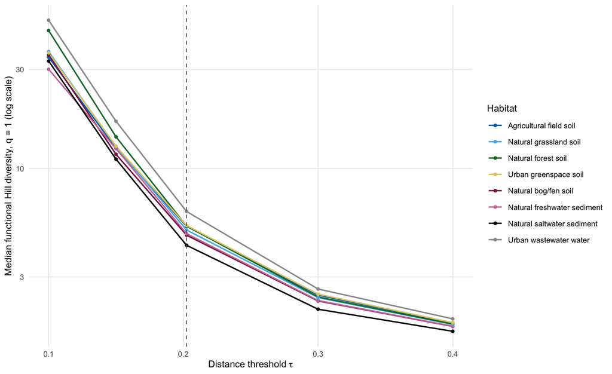

```r
tau_data <- do.call(rbind, tau_results)
tau_data$habitat <- sample_metadata$habitat_label[
  match(tau_data$sample, sample_metadata$sample_id)
]
stopifnot(!anyNA(tau_data$habitat), all(is.finite(tau_data$value)))
tau_median <- aggregate(value ~ habitat + tau, data = tau_data, FUN = median)
tau_median$habitat <- factor(tau_median$habitat, levels = habitat_levels)
ggplot2::ggplot(tau_median,
                ggplot2::aes(x = tau, y = value, colour = habitat)) +
  ggplot2::geom_line(linewidth = 0.7) +
  ggplot2::geom_point(size = 1.2) +
  ggplot2::geom_vline(xintercept = functional_tau, linetype = "dashed",
                      colour = "grey40") +
  ggplot2::scale_colour_manual(values = habitat_colours) +
  ggplot2::scale_y_log10() +
  ggplot2::labs(x = expression("Distance threshold" ~ tau),
                y = "Median functional Hill diversity, q = 1 (log scale)",
                colour = "Habitat") +
  ggplot2::theme_minimal(base_size = 10) +
  ggplot2::theme(panel.grid.minor = ggplot2::element_blank())
```

*Median functional diversity per habitat across thresholds. The dashed line is the mean pairwise distance used elsewhere in this chapter.*

The habitat with the highest median functional diversity is Urban wastewater water at 5 of the 5 thresholds tested.

## 7.5 Community-level trait profiles

The abundance-weighted mean completeness of each function in a sample, the community-weighted mean (CWM), describes the average functional capacity of the community without any threshold. It weights each MAG by its relative abundance within the profile.

```r
relative_profiles <- sweep(overview_abundance, 2, colSums(overview_abundance),
                           "/")
cwm <- t(relative_profiles) %*% as.matrix(functional_traits)
stopifnot(identical(rownames(cwm), sample_metadata$sample_id),
          all(cwm >= -1e-10 & cwm <= 1 + 1e-10))
cwm_habitat <- aggregate(as.data.frame(cwm),
                         by = list(habitat = sample_metadata$habitat_label),
                         FUN = mean)
cwm_long <- reshape(
  cwm_habitat, direction = "long", idvar = "habitat",
  varying = colnames(cwm), v.names = "cwm", timevar = "code",
  times = colnames(cwm)
)
cwm_long$label <- paste(cwm_long$code,
                        function_labels$Function[match(cwm_long$code,
                                                       function_labels$Code_function)])
cwm_long$domain <- function_labels$Domain[match(cwm_long$code,
                                                function_labels$Code_function)]
cwm_long$habitat <- factor(cwm_long$habitat, levels = habitat_levels)
```

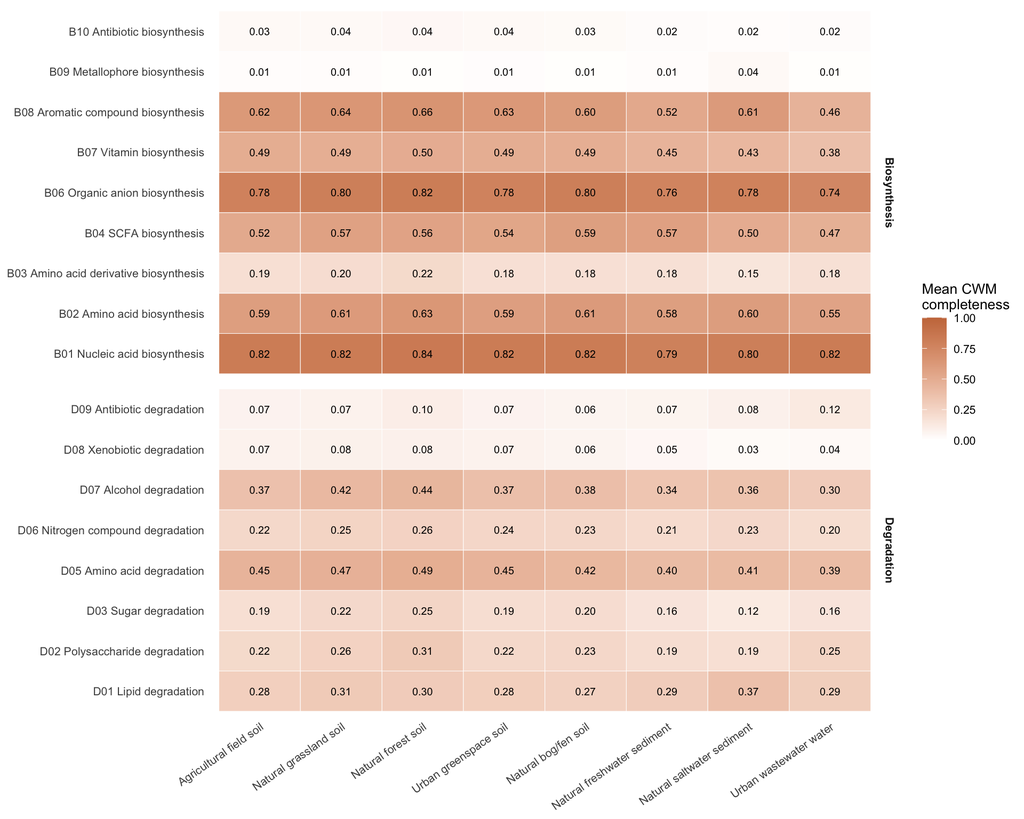

```r
ggplot2::ggplot(cwm_long, ggplot2::aes(x = habitat, y = label, fill = cwm)) +
  ggplot2::geom_tile(colour = "white") +
  ggplot2::geom_text(ggplot2::aes(label = sprintf("%.2f", cwm)), size = 2.6) +
  ggplot2::facet_grid(rows = ggplot2::vars(domain), scales = "free_y",
                      space = "free_y") +
  ggplot2::scale_fill_gradient(low = "#ffffff", high = "#c9784a",
                               limits = c(0, 1)) +
  ggplot2::scale_x_discrete(guide = ggplot2::guide_axis(angle = 35)) +
  ggplot2::labs(x = NULL, y = NULL, fill = "Mean CWM\ncompleteness") +
  ggplot2::theme_minimal(base_size = 10) +
  ggplot2::theme(panel.grid = ggplot2::element_blank(),
                 strip.text = ggplot2::element_text(face = "bold"))
```

*Mean community-weighted completeness of each function across the 45 samples of a habitat. Values range from zero (no MAG carries the function) to one (the community is dominated by MAGs with the complete function).*

The function that differs most between habitats is B08 Aromatic compound biosynthesis, from 0.46 in Urban wastewater water to 0.66 in Natural forest soil.

## 7.6 Partitioning functional diversity

`hillpart()` partitions functional diversity across samples, habitat classes and the full panel, as for neutral and phylogenetic diversity in the diversity chapter.

```r
functional_metadata <- data.frame(
  habitat_class = sample_metadata$habitat_class,
  row.names = sample_metadata$sample_id
)
partition_functional <- hilldiv3::hillpart(
  overview_abundance, q = c(0, 1, 2), dist = functional_dist,
  tau = functional_tau, hierarchy = ~ habitat_class,
  metadata = functional_metadata, type = "functional"
)
```

```r
partition_functional <- plain_result(partition_functional)
stopifnot(all(is.finite(partition_functional$diversity)))
f_within <- partition_functional[partition_functional$scale == "habitat_class",
                                 c("q", "beta")]
f_total <- partition_functional[partition_functional$scale == "total",
                                c("q", "beta", "diversity")]
f_alpha <- partition_functional[partition_functional$scale == "sample",
                                c("q", "diversity")]
names(f_alpha)[2] <- "Alpha diversity"
names(f_within)[2] <- "Within habitats"
names(f_total)[2:3] <- c("Between habitats", "Gamma diversity")
partition_functional_table <- Reduce(function(a, b) merge(a, b, by = "q"),
                                     list(f_alpha, f_within, f_total))
knitr::kable(partition_functional_table, digits = 2)
```

| q | Alpha diversity | Within habitats | Between habitats | Gamma diversity |
| --- | --- | --- | --- | --- |
| 0 | 8.05 | 1.00 | 1.00 | 8.08 |
| 1 | 6.39 | 1.06 | 1.03 | 6.99 |
| 2 | 5.67 | 1.09 | 1.05 | 6.45 |

*Hierarchical partition of functional Hill numbers. Beta factors describe sample-to-habitat and habitat-to-panel turnover.*

At $q=1$ the functional beta factors are 1.06 from samples to habitats and 1.03 from habitats to the full panel. These are much closer to one than the neutral and phylogenetic factors: communities in different habitats consist of different MAGs but carry largely overlapping functions.

## 7.7 Pairwise functional dissimilarity

`hillpair()` compares every pair of samples, using the functional layer. As in the pairwise chapter, we use the C dissimilarity, here at $q=1$.

```r
pair_functional <- hilldiv3::hillpair(
  overview_abundance, q = 1, metric = "C", dist = functional_dist,
  tau = functional_tau, type = "functional", out = "tibble"
)
```

```r
pair_functional <- plain_result(pair_functional)
fd_ids <- sample_metadata$sample_id
fd_first <- match(pair_functional$first, fd_ids)
fd_second <- match(pair_functional$second, fd_ids)
stopifnot(nrow(pair_functional) == choose(length(fd_ids), 2L),
          !anyNA(fd_first), !anyNA(fd_second), all(fd_first < fd_second),
          all(is.finite(pair_functional$value)),
          all(pair_functional$value >= -1e-10 &
                pair_functional$value <= 1 + 1e-10))
pair_functional$comparison <- ifelse(
  sample_metadata$habitat_label[fd_first] ==
    sample_metadata$habitat_label[fd_second],
  "Within habitat", "Between habitats"
)
pair_summary <- aggregate(
  value ~ comparison, data = pair_functional,
  FUN = function(x) sprintf("%.2f [%.2f–%.2f]", median(x),
                            unname(quantile(x, 0.25)),
                            unname(quantile(x, 0.75)))
)
knitr::kable(pair_summary, col.names = c("Pairs", "Functional C, q = 1"),
             row.names = FALSE)
```

| Pairs | Functional C, q = 1 |
| --- | --- |
| Between habitats | 0.07 [0.04–0.12] |
| Within habitat | 0.03 [0.01–0.07] |

*Median [interquartile range] of functional C dissimilarity. Zero means identical functional communities and one means no functional overlap.*

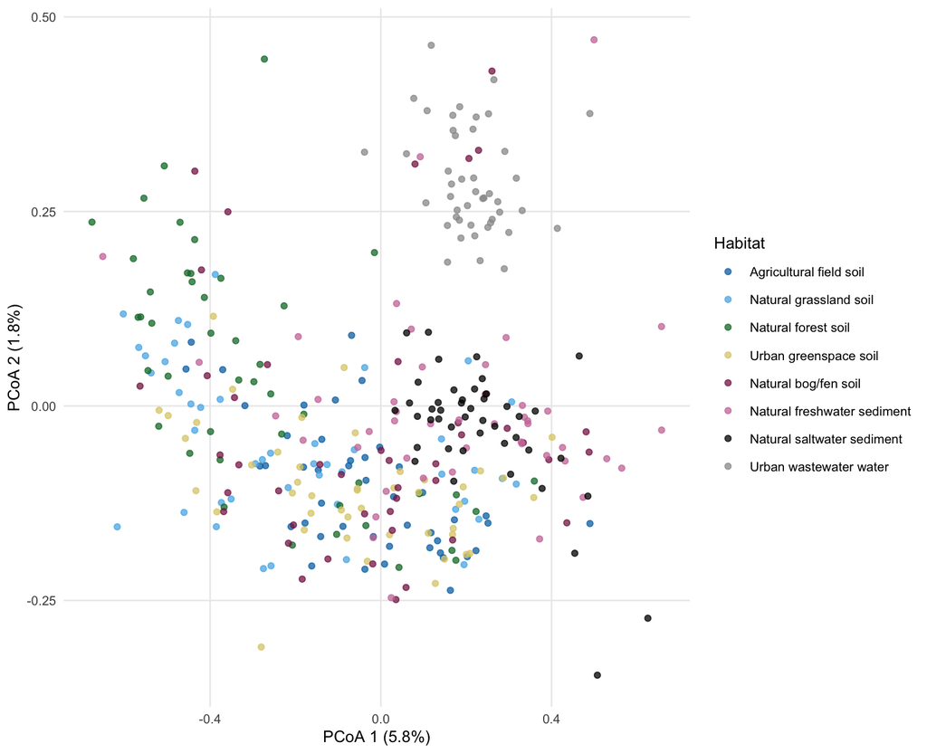

```r
ggplot2::ggplot(fd_points,
                ggplot2::aes(x = PCoA1, y = PCoA2, colour = habitat)) +
  ggplot2::geom_point(alpha = 0.75, size = 1.5) +
  ggplot2::scale_colour_manual(values = habitat_colours) +
  ggplot2::labs(x = sprintf("PCoA 1 (%.1f%%)", fd_variance[1]),
                y = sprintf("PCoA 2 (%.1f%%)", fd_variance[2]),
                colour = "Habitat") +
  ggplot2::theme_minimal(base_size = 10) +
  ggplot2::theme(panel.grid.minor = ggplot2::element_blank())
```

*Each point is one sample. Axis percentages are the shares of positive eigenvalues after the Cailliez correction.*

## 7.8 Functional view of the Actinomycetota turnover

The shares chapter found a nearly stable Actinomycetota total in agricultural field and natural grassland soils, with more Gaiellales in fields and more Streptosporangiales in grasslands. Do these two orders carry different functions, so that the swap changes what the community can do? We answer at the finer **element** level, such as individual amino acids, sugars or vitamins, which resolves more than the 17 function-level traits above.

```r
element_traits <- data.table::fread(
  cmd = "xz -dc data/mag_gift_elements.tsv.xz",
  data.table = FALSE, check.names = FALSE
)
stopifnot(identical(element_traits$genome_id, genome_metadata$genome_id))
rownames(element_traits) <- element_traits$genome_id
element_traits$genome_id <- NULL
element_traits <- element_traits[, colSums(element_traits) > 0, drop = FALSE]
element_matrix <- as.matrix(element_traits)

element_labels <- unique(distillR::GIFT_db[c("Code_element", "Element",
                                             "Function")])
element_labels <- element_labels[match(colnames(element_matrix),
                                       element_labels$Code_element), ]
element_labels$label <- sprintf("%s %s (%s)", element_labels$Code_element,
                                element_labels$Element,
                                tolower(element_labels$Function))
stopifnot(!anyNA(element_labels$Element))

element_dist <- hilldiv3::traits2dist(element_traits, method = "gower")
dimnames(element_dist) <- list(genome_metadata$genome_id,
                               genome_metadata$genome_id)
element_tau <- mean(element_dist[upper.tri(element_dist)])
```

`traits2dist()` now uses the 161 of 170 elements that are present in at least one MAG (the others, including the protein-degradation elements, are absent from every MAG). We again set $\tau$ to the mean pairwise distance, 0.22.

The four disjoint sets are the two orders, the remaining Actinomycetota, and everything outside the phylum. They cover all representatives, so contributions add up to the total. We compare the mean field and grassland profiles, as in the dissimilarity analysis of the shares chapter.

```r
actino_ids <- genome_metadata$genome_id[phylum == "Actinomycetota"]
fa_sets <- lapply(actino_orders, function(name) {
  actino_ids[genome_metadata[match(actino_ids, genome_metadata$genome_id),
                             "order"] == paste0("o__", name)]
})
names(fa_sets) <- actino_orders
fa_sets[["Remaining Actinomycetota"]] <- setdiff(actino_ids,
                                                 unlist(fa_sets))
fa_sets[["Outside Actinomycetota"]] <- setdiff(genome_metadata$genome_id,
                                               actino_ids)
stopifnot(all(lengths(fa_sets) > 0L),
          sum(lengths(fa_sets)) == nrow(genome_metadata),
          setequal(unlist(fa_sets, use.names = FALSE),
                   genome_metadata$genome_id))

fa_profiles <- function(field, grassland) {
  out <- cbind(rowMeans(overview_abundance[, field, drop = FALSE]),
               rowMeans(overview_abundance[, grassland, drop = FALSE]))
  colnames(out) <- contrast_habitats
  out
}
fa_field <- sample_metadata$habitat_label == contrast_habitats[1]
fa_grass <- sample_metadata$habitat_label == contrast_habitats[2]
fa_matched <- sample_metadata$project_id %in% c("P01_1", "P02_1")
```

### 7.8.1 Functional dissimilarity and the contribution of each set

`hillcontrib()` splits the $q=1$ C dissimilarity between the two mean profiles into contributions from each set. Neutral dissimilarity uses abundances alone; functional dissimilarity adds the element distance, so MAGs with similar elements count as the same functional type.

```r
fa_mean <- fa_profiles(fa_field, fa_grass)
fa_neutral <- hilldiv3::hillcontrib(
  fa_mean, q = 1, metric = "C", type = "neutral", sets = fa_sets
)
fa_functional <- hilldiv3::hillcontrib(
  fa_mean, q = 1, metric = "C", dist = element_dist, tau = element_tau,
  type = "functional", sets = fa_sets
)
```

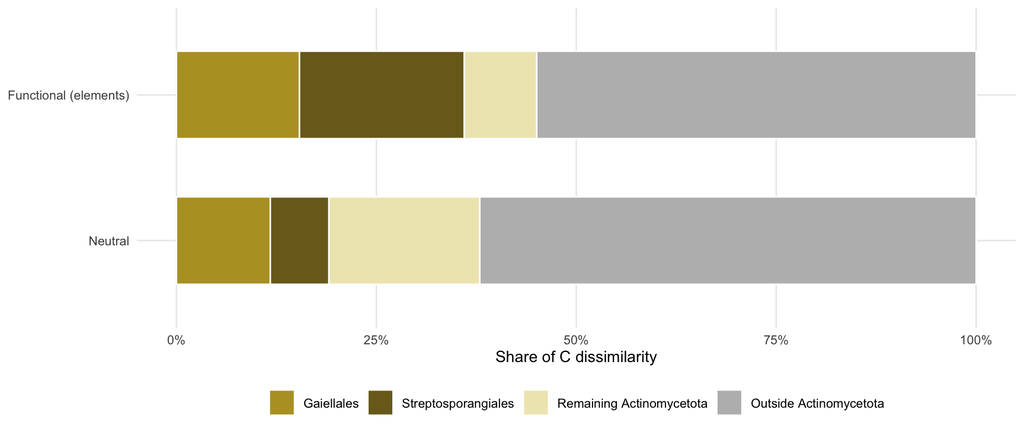

```r
fa_plot <- rbind(
  data.frame(type = "Neutral", fa_neutral[c("set", "share")]),
  data.frame(type = "Functional (elements)", fa_functional[c("set", "share")])
)
fa_plot$set <- factor(fa_plot$set, levels = rev(c(
  actino_orders, "Remaining Actinomycetota", "Outside Actinomycetota"
)))
fa_plot$type <- factor(fa_plot$type,
                       levels = c("Neutral", "Functional (elements)"))
ggplot2::ggplot(fa_plot, ggplot2::aes(x = share, y = type, fill = set)) +
  ggplot2::geom_col(width = 0.6, colour = "white") +
  ggplot2::scale_fill_manual(values = c(
    Gaiellales = "#B79F2B", Streptosporangiales = "#7A6A1F",
    `Remaining Actinomycetota` = "#EFE7BC",
    `Outside Actinomycetota` = "#BBBBBB"
  ), breaks = c(actino_orders, "Remaining Actinomycetota",
                "Outside Actinomycetota")) +
  ggplot2::scale_x_continuous(labels = scales::label_percent()) +
  ggplot2::labs(x = "Share of C dissimilarity", y = NULL, fill = NULL) +
  ggplot2::theme_minimal(base_size = 10) +
  ggplot2::theme(panel.grid.minor = ggplot2::element_blank(),
                 legend.position = "bottom")
```

*Share of the $q=1$ C dissimilarity between mean field and grassland profiles attributed to each set, for abundance alone (neutral) and with the element distance (functional).*

Neutral C between the two mean profiles is 0.285, while functional C is only 0.010 at this threshold: most of the abundance turnover replaces MAGs with similar elements. Gaiellales and Streptosporangiales hold only 3.2% of the representatives, yet they account for 19% of the neutral and 36% of the functional dissimilarity. The two orders therefore explain a larger part of the functional turnover than of the abundance turnover.

```r
fa_robust_table <- data.frame(
  fa_robust$Comparison,
  sprintf("%.3f", fa_robust$neutral),
  sprintf("%.3f", fa_robust$functional),
  sprintf("%.0f%%", 100 * fa_robust$share_neutral),
  sprintf("%.0f%%", 100 * fa_robust$share_functional)
)
knitr::kable(fa_robust_table, col.names = c(
  "Comparison", "Neutral C", "Functional C",
  "Orders' share of neutral C", "Orders' share of functional C"
))
```

| Comparison | Neutral C | Functional C | Orders’ share of neutral C | Orders’ share of functional C |
| --- | --- | --- | --- | --- |
| All samples, mean tau | 0.285 | 0.010 | 19% | 36% |
| All samples, tau = 0.10 | 0.285 | 0.214 | 19% | 23% |
| All samples, tau = 0.40 | 0.285 | 0.000 | 19% | 27% |
| Project-matched samples, mean tau | 0.314 | 0.014 | 23% | 55% |
| Higher-quality MAGs only, mean tau | 0.264 | 0.013 | 12% | 18% |

### 7.8.2 Do the two orders offset each other?

For each element we split the field-minus-grassland difference in community-weighted mean completeness into the part contributed by each set. Positive values mean higher completeness in fields. If the swap between orders left the community’s functions unchanged, Gaiellales and Streptosporangiales would contribute opposite amounts for every element.

```r
fa_by_set <- fa_decompose(fa_mean)
fa_elements <- data.frame(
  code = rownames(fa_by_set), fa_by_set, check.names = FALSE,
  label = element_labels$label[match(rownames(fa_by_set),
                                     element_labels$Code_element)]
)
fa_elements$orders <- fa_elements$Gaiellales + fa_elements$Streptosporangiales
fa_elements$total <- rowSums(fa_by_set)
stopifnot(!anyNA(fa_elements$label))
fa_top <- fa_elements[order(-abs(fa_elements$orders)), ][1:12, ]
```

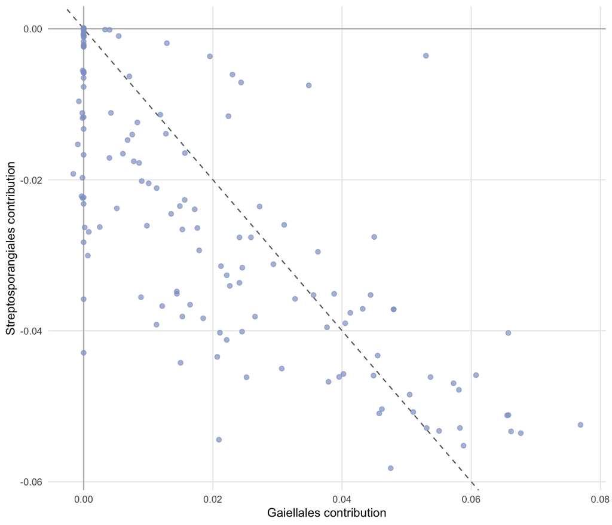

```r
ggplot2::ggplot(fa_elements,
                ggplot2::aes(x = Gaiellales, y = Streptosporangiales)) +
  ggplot2::geom_hline(yintercept = 0, colour = "grey70") +
  ggplot2::geom_vline(xintercept = 0, colour = "grey70") +
  ggplot2::geom_abline(slope = -1, intercept = 0, linetype = "dashed",
                       colour = "grey40") +
  ggplot2::geom_point(colour = type_colours[["Functional"]], alpha = 0.7, size = 1.6) +
  ggplot2::labs(x = "Gaiellales contribution",
                y = "Streptosporangiales contribution") +
  ggplot2::theme_minimal(base_size = 10) +
  ggplot2::theme(panel.grid.minor = ggplot2::element_blank())
```

*Each point is one element. The dashed line marks complete offset: the two orders contribute equal and opposite amounts.*

The contributions of the two orders are negatively correlated across the 161 elements (r = -0.78). Summed over elements, their absolute contributions are 4.1 times larger than the absolute contribution of the two orders combined, so most of what one order adds is cancelled by the other. The offset is partial: the two orders together still shift the completeness of individual elements.

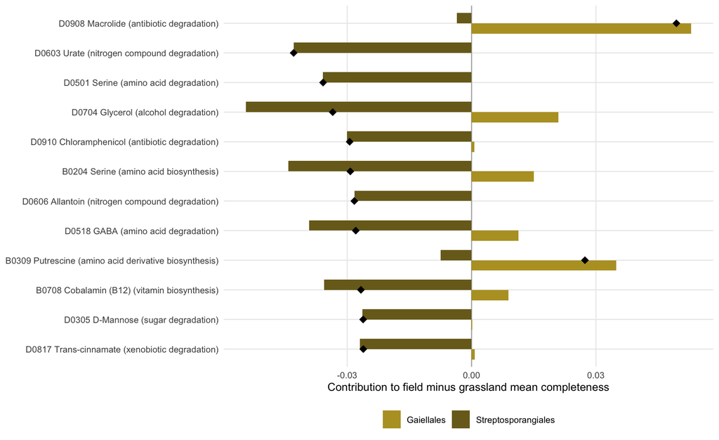

```r
fa_top_long <- rbind(
  data.frame(label = fa_top$label, set = "Gaiellales",
             value = fa_top$Gaiellales),
  data.frame(label = fa_top$label, set = "Streptosporangiales",
             value = fa_top$Streptosporangiales)
)
fa_top_long$label <- factor(fa_top_long$label, levels = rev(fa_top$label))
fa_top$label <- factor(fa_top$label, levels = rev(fa_top$label))
ggplot2::ggplot(fa_top_long, ggplot2::aes(x = value, y = label)) +
  ggplot2::geom_vline(xintercept = 0, colour = "grey70") +
  ggplot2::geom_col(ggplot2::aes(fill = set), position = "dodge",
                    width = 0.7) +
  ggplot2::geom_point(data = fa_top, ggplot2::aes(x = orders, y = label),
                      shape = 18, size = 3) +
  ggplot2::scale_fill_manual(values = c(Gaiellales = "#B79F2B",
                                        Streptosporangiales = "#7A6A1F")) +
  ggplot2::labs(x = "Contribution to field minus grassland mean completeness",
                y = NULL, fill = NULL) +
  ggplot2::theme_minimal(base_size = 10) +
  ggplot2::theme(panel.grid.minor = ggplot2::element_blank(),
                 legend.position = "bottom")
```

*The twelve elements with the largest net effect of the two orders. Bars are the contribution of each order; the diamond is their sum.*

The largest net effect is for D0908 Macrolide (antibiotic degradation): Gaiellales contributes +0.053 and Streptosporangiales -0.004, so the orders together shift it by +0.049.

Of these 12 elements, 9 are degradation elements for which Streptosporangiales, enriched in grasslands, raises grassland completeness. The replacement of Gaiellales by Streptosporangiales is therefore not functionally neutral at the level of individual elements, even though the overall functional dissimilarity is small.

## 7.9 Trait validation and sensitivity to MAG quality

Before relying on the traits we check that they behave as expected for clades whose metabolism is well known, and that the main results do not simply track how complete a MAG is.

```r
validation_phyla <- names(which(table(phylum) >= 60L))
validation_codes <- c("B01", "B02", "B07", "D02")
validation <- t(vapply(validation_phyla, function(name) {
  colMeans(functional_traits[phylum == name, validation_codes])
}, numeric(length(validation_codes))))
validation <- validation[order(-validation[, "D02"]), ]
antibiotic_max <- max(vapply(validation_phyla, function(name) {
  mean(functional_traits[phylum == name, "B10"])
}, numeric(1)))
stopifnot(antibiotic_max < 0.05)
colnames(validation) <- function_labels$Function[
  match(validation_codes, function_labels$Code_function)
]
knitr::kable(validation, digits = 2)
```

|  | Nucleic acid biosynthesis | Amino acid biosynthesis | Vitamin biosynthesis | Polysaccharide degradation |
| --- | --- | --- | --- | --- |
| Acidobacteriota | 0.84 | 0.58 | 0.46 | 0.45 |
| Planctomycetota | 0.81 | 0.58 | 0.43 | 0.38 |
| Bacteroidota | 0.81 | 0.46 | 0.39 | 0.35 |
| Verrucomicrobiota | 0.66 | 0.54 | 0.48 | 0.35 |
| Chloroflexota | 0.65 | 0.45 | 0.27 | 0.31 |
| Actinomycetota | 0.78 | 0.59 | 0.42 | 0.28 |
| Bacillota | 0.77 | 0.49 | 0.36 | 0.26 |
| Cyanobacteriota | 0.83 | 0.66 | 0.62 | 0.24 |
| Pseudomonadota | 0.82 | 0.65 | 0.48 | 0.19 |
| Desulfobacterota | 0.75 | 0.61 | 0.47 | 0.11 |
| Patescibacteria | 0.35 | 0.03 | 0.02 | 0.06 |
| Halobacteriota | 0.79 | 0.53 | 0.32 | 0.05 |
| Thermoproteota | 0.67 | 0.33 | 0.29 | 0.04 |

*Mean completeness of four functions among the phyla with at least 60 representatives.*

The patterns match expectations. Patescibacteria, whose reduced genomes depend on other cells, score near zero for amino acid (0.03) and vitamin (0.02) biosynthesis, and well below the other phyla for nucleic acids (0.35 against at least 0.65). Polysaccharide degradation is highest in Acidobacteriota, Planctomycetota, Bacteroidota, groups known for degrading complex carbohydrates, and lowest in Thermoproteota. KEGG orthologs do not resolve antibiotic biosynthesis: it stays below 0.05 in every phylum, including the Actinomycetota.

```r
trait_cors <- vapply(c("genome_size", "checkm2_completeness"), function(v) {
  stats::median(abs(vapply(colnames(functional_traits), function(f) {
    stats::cor(functional_traits[[f]], genome_metadata[[v]],
               method = "spearman")
  }, numeric(1))))
}, numeric(1))
```

Trait completeness rises with genome size and CheckM2 completeness: the median absolute Spearman correlation across the 17 functions is 0.54 with genome size and 0.21 with completeness. Larger genomes do carry more metabolic functions, but incomplete MAGs also miss genes, so trait values are lower bounds. To see whether the conclusions depend on this, we repeat the analyses with the 3186 representatives that have CheckM2 completeness of at least 80% and contamination of at most 10%, renormalizing each profile.

```r
quality_profiles <- overview_abundance[quality_keep, , drop = FALSE]
quality_profiles <- sweep(quality_profiles, 2, colSums(quality_profiles), "/")
quality_dist <- functional_dist[quality_keep, quality_keep]
quality_functional <- hilldiv3::hilldiv(
  quality_profiles, q = 1, dist = quality_dist,
  tau = mean(quality_dist[upper.tri(quality_dist)]), type = "functional"
)
```

```r
quality_functional <- plain_result(quality_functional)
quality_medians <- tapply(
  quality_functional$value,
  sample_metadata$habitat_label[match(quality_functional$sample,
                                      sample_metadata$sample_id)],
  median
)[habitat_levels]
all_medians <- tapply(fd_wide$Functional, fd_wide$habitat,
                      median)[habitat_levels]
quality_cwm <- t(quality_profiles) %*%
  as.matrix(functional_traits[quality_keep, ])
cwm_agreement <- vapply(colnames(cwm), function(f) {
  stats::cor(tapply(cwm[, f], sample_metadata$habitat_label,
                    mean)[habitat_levels],
             tapply(quality_cwm[, f], sample_metadata$habitat_label,
                    mean)[habitat_levels], method = "spearman")
}, numeric(1))
knitr::kable(
  data.frame(Habitat = habitat_levels,
             `All MAGs` = unname(all_medians),
             `Higher-quality MAGs` = unname(quality_medians),
             check.names = FALSE),
  digits = 2
)
```

| Habitat | All MAGs | Higher-quality MAGs |
| --- | --- | --- |
| Agricultural field soil | 5.26 | 3.65 |
| Natural grassland soil | 5.05 | 3.62 |
| Natural forest soil | 5.28 | 3.78 |
| Urban greenspace soil | 5.31 | 3.70 |
| Natural bog/fen soil | 4.77 | 3.43 |
| Natural freshwater sediment | 4.85 | 3.73 |
| Natural saltwater sediment | 4.26 | 3.37 |
| Urban wastewater water | 6.20 | 5.52 |

*Median functional diversity ($q=1$) per habitat with all representatives and with the higher-quality subset. Each uses its own mean pairwise distance as $\tau$.*

The subset holds a median of 62% of each sample’s profile. Absolute functional diversity is lower, but the habitat ranking is similar (Spearman 0.81) and Urban wastewater water remains highest. The habitat means of the community-weighted trait profiles agree between the two sets (median Spearman 0.95 across functions, minimum 0.69).

Within the Actinomycetota analysis, the higher-quality row of the robustness table keeps the negative correlation between the orders (r = -0.72) and a small functional dissimilarity, but the orders’ share of functional dissimilarity falls to 18% against 12% neutral. We therefore read that excess as a modest, not a large, effect.

## 7.10 Interpretation and limits

These traits come from gene presence in KEGG ortholog annotations. They describe genomic potential, not expressed activity, and cover only functions that KEGG orthologs and EC numbers can define. Protein degradation, which needs MEROPS peptidase families, is left out. Each representative’s abundance stands for its 95% ANI cluster, which need not share its gene content.

Functional diversity depends on the trait set and on $\tau$; compare values only within one choice of both. The pairwise and ordination summaries describe this selected panel. Pairs sharing samples are dependent, and habitat class is partly confounded with sampling year, so none of these comparisons is a formal test of a habitat effect. Relative abundances also cannot support read-count rarefaction or sampling-depth uncertainty estimates.